# SWAT Evaluation

Jeffrey Smith

2018-03-15

# Introduction

# Accuracy

The results of analysis using this analytic tool are clear and appear to be accurate. It seems that the count information used in this analytic focuses on the counts of various factor levels found in the data and the time computations are performed via `lubridate`.

# Compilation

Once the package was installed and the shiny application called, this analytic worked flawlessly. No errors were encountered when executing the code according to the documentation.

# Ease of Use

Deployment of this analytic was done by calling the shiny application through the use of `SWAT::run_my_app('SWAT')` command in the console. Upon execution, the user is presented with an instruction tab. This sheet includes information designed to explain the inner workings of the application’s functionality and provides information on each sequential tab. The instruction sheet presents a clear description of how the tool’s features work.

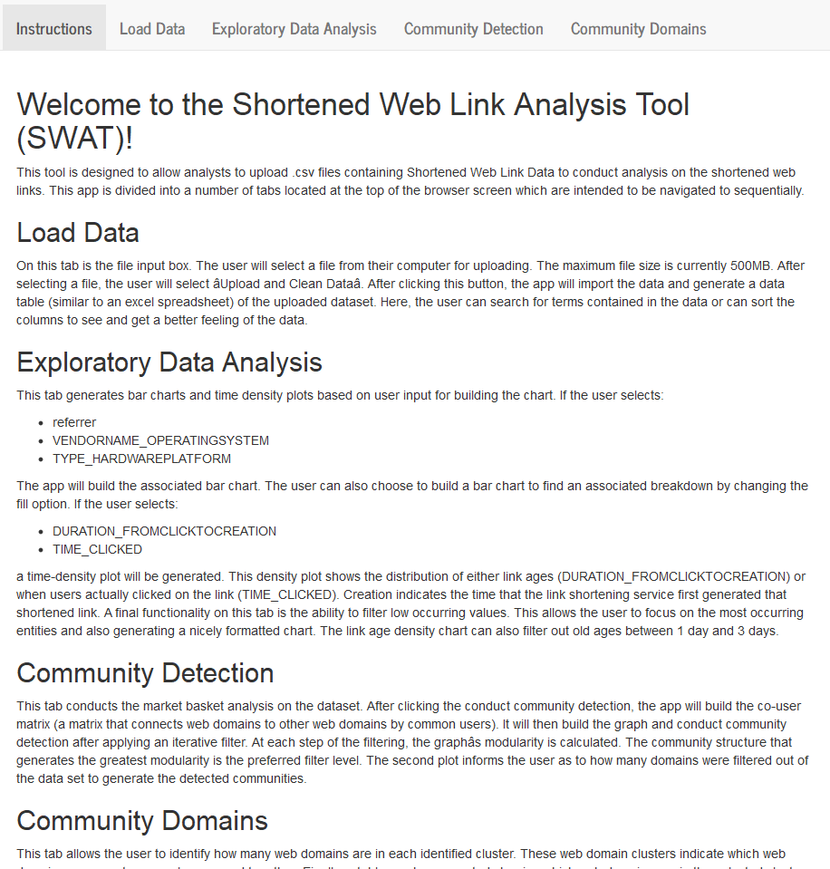

Instruction Page